# Ok il prezzo è giusto

Uno studio sui potenziali fattori causali dei prezzi di affitto di Airbnb

Danilo Perrini

2019-01-27

[figure not shown]

A tutti piace viaggiare, diciamocelo, tuttavia non tutti hanno i soldi per poter pagare un hotel in centro città, bisogna dunque scendere a compromessi. Ci viene in aiuto a tale scopo AirBnB.

*“`Airbnb` è un portale online che mette in contatto persone in cerca di un alloggio o di una camera per brevi periodi, con persone che dispongono di uno spazio extra da affittare, generalmente privati. Il sito fu aperto nell’ottobre del 2007 da Brian Chesky, Joe Gebbia e Nathan Blecharczyk. Al giugno 2012 contava alloggi in oltre 26.000 città in 192 paesi e raggiunse 10 milioni di notti prenotate in tutto il mondo. Gli annunci includono sistemazioni quali stanze private, interi appartamenti, castelli e ville, ma anche barche, baite, case sugli alberi, igloo, isole private e qualsiasi altro tipo di alloggio.”*

[Wikpedia source](https://it.wikipedia.org/wiki/Airbnb)

In questo lavoro il mio obbiettivo sarà quello di cercare di capire quali siano i fattori che influenzano i prezzi di affito di questo sito; questo perchè sicuramente può essere utile in termini di risparmio ed in secondo luogo, se interessanti, le informazioni che ne usciranno potrebbero essere utilizzate dagli attuali profili attivi per apportare semplici migliorie che sarebbero però in grado di permettere ai propietari di regolare il proprio prezzo.

Per raggiungere questo obbiettivo, ho deciso di analizzare i `dati` relativi a circa 70’000 annunci diramati nelle città di Chicago, Boston, Washington DC, Los Angeles, San Francisco e New York. Per ogni annuncio sono state raccolte 29 variabili, tra le quali alcune contengono informazioni basilari incentrate sull’oggetto dell’affitto come il numero di stanze, il tipo di posto letto che si affita e la posizione, altre invece più in linea con il profilo dell’utente che ha pubblicato l’annuncio, come per esempio da quando è attivo il profilo, se possiede o meno un immagine o se è un profilo verificato o meno, le ultime infine sono informazioni contenenti date, come per esempio il giorno della prima e dell’ ultima recensione ricevuta, ovviamente se ci sono.

[*Keaggle*](https://www.kaggle.com/stevezhenghp/airbnb-price-prediction)

Viste le variabili, è già possibile farsi un’ idea dei potenziali fattori che influenzano i prezzi. Chi ha avuto a che fare con il famoso dataset ames si sarà reso conto che San Francisco è una città piuttosto cara, è infatti intuitivo immaginare che posizione, numero di letti, numero di persone che possono dormire ecc siano alla base del prezzamento di un annuncio.

## Esplorativa

La prima cosa che ci viene in mente di guardare per studiare il prezzo degli affitti è ovviamente la loro distribuzione condizionata alla città di riferimento

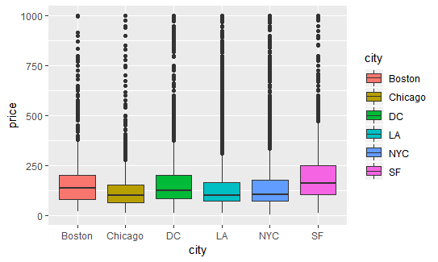

Dai box-plot già si nota un andamento asimmetrico positivo che ritroviamo negli istogrammi condizionati, anche se vediamo che le mediane, in generale, non si distanziano troppo.

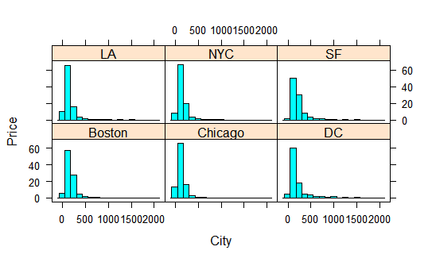

Stesse considerzioni possono essere fatte nei confronti di variabili come il numero di bagni, il numero di stanze, il tipo di stanza o anche il tipo di posto letto. Se consideriamo quest’ultima variabile citata, si vede che richiedere di dormire in un vero letto è generalmente la richiesta più costosa che possiamo effettuare tra le proposte possibili.

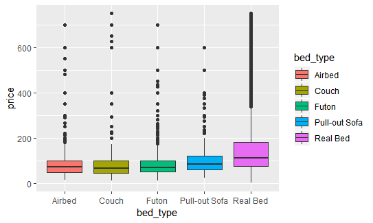

Anche se ci spostiamo sulla variabile room_type possiamo fare alcune considerazioni utili,

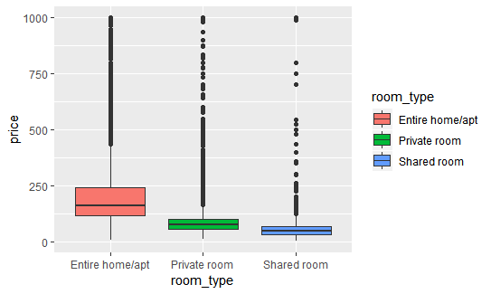

poichè, non solo condizionando il prezzo al tipo di stanza si nota una evidente differenza di distribuzioni, inoltre presenta anche una grande differnza in termini di numerosità.

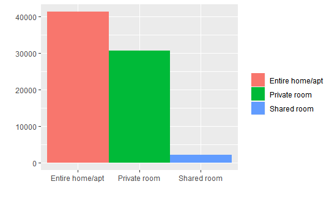

Possiamo spendere alcune parole anche sulle densità condizionate. Si nota immediatamente che, anzitutto le mode sono collocate in tre prezzi diversi, inoltre le densità condizionate a shared room e private room sono già praticamente spente in corrispondenza di 200 euro, ovvero quasi non esistono stanze singole o condivse che siano a più di 200 euro.

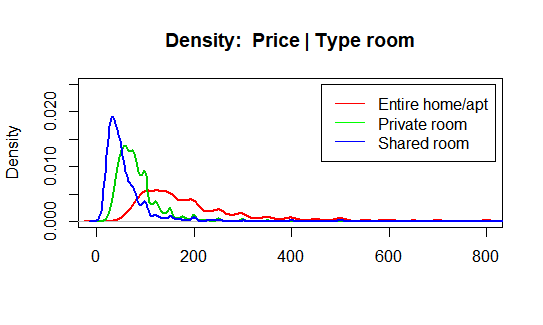

## Analisi

Come abbiamo visto, diverse variabili ci lasciano intuire la loro importanza, motivo per il quale mi propongo di andare a cercare qualcosa di più insolito all’interno di questi dati. Nell’insieme delle variabili raccolte c’è anche una variabile riguardante la descrizione del posto letto/appartamento ed un’altra contenente l’elenco dei servizi disponibili di cui l’affittuario può usufruire. Voglio quindi concentrarmi su queste due e vedere se è possibile trarre delle conclusioni utili. Per cominciare, ho deciso di farmi un’idea di cosa stavo affrontando e ho quindi letto le descrizioni dell’annuncio più costoso

```
## [1] "Beverly Hills gated, jetliner view contemporary estate;  tennis court, gym, 5 bd/4.5 ba.  With a  motor court and 5 car parking within the property's gates, and over half acre of lushly landscaped outdoor entertainment area, this home is an entertainer's paradise. The property includes a lar…
```

e di quello più economico

```
## [1] "Comfortable dwellings .. My comfy home is for guest travelers and college students on a budget..!! I'm a 3min walk to the 6 train which is 30 mins away from Grand Central Station, Times Square, 34th St and a lot of other tourist areas..  Most of my neighbours are homeowners and are friendly …
```

Insomma, spiaggia palestra piscina campo da tennis da una parte e bronx dall’altra.

Mi sono quindi munito di materiale sul text mining e ho deciso di cercare le parole più diffuse nelle descrizioni e nella lista dei servizi degli annunci, iniziando proprio da queste ultime.

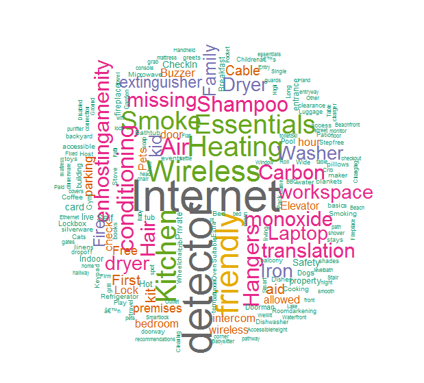

Dal wordcloud risultante si notano subito parole come “Internet” o “wireless”, che considerato che ormai ci troviamo nella generazione dei nativi digitali, sono più che giustificate. Più inaspettate sono parole come “monoxide” e “detector”, che in realtà sono riferite allo smoke detector e al monoxide carbon detector il che le rende assolutamente meno preoccupanti. “Heating”, ovvero riscaldamento, compare anche molto spesso, “buzzer” riferito a buzzer intercom, che è il citofono con telecamera, è anch’esso tra i più quotati.

Dopo aver replicato lo stesso lavoro anche per le parole riguardanti le descrizioni, ho deciso di dedicarmi alle informazioni che possono essere contenute nelle date, analizzando quindi le variabili “host since”, “last review” e “first review”. Per ognuna ho creato una dummy per ogni anno, per un totale di 32 variabili aggiuntive. Mettendo insieme i dati iniziali, le variabili create partendo dai servizi e dalle descrizioni e quelle create dalle informazioni temporali, sono passato da 30 variabili ad averne circa 800 finali di cui valutare l’importanza.

Studiando un semplice modello di regressione i coefficienti significativamente diversi da zero risultano 820 su 832, non troppo informativo direi, o forse fin troppo. Decido quindi di applicare correzioni studiate per dati ad alta dimensionalità e applicando la correzzione di Bonferroni passo da 820 a circa 200, possiamo migliorare ancora la precisione usando un processo di stability selection che mi porta ad avere sole 44 variabili ritenute veramente significative.

## Conclusioni

Tra le variabili che alla fine vengono considerate come veramente importanti non consideriamo quelle relative a locazione del posto ecc, di cui abbiamo già parlato ma ci concentriamo invece su quelle create dalle date, dai servizi e dalle descrizioni. Le variabili risultate veramente importanti sono quindi “Dryer”, “Cable TV”, “Buzzer/Weirless intercom”, “Elevator”, “Indoor fireplaces” (camino interno), “Gym”, “Doorman”, “heart”, “ultima recensione na” e “ultima recensione 2017”. Se dovessi quindi dare un consiglio a chi vuole fare un investimento sulla proprietà, per accrescerne il valore e quindi il prezzo di affitto, gli direi di investire in asciugatrici, tv via cavo e citofono con fotocamera o al limite in un portinaio, considerato che mi sembrano tutte opzioni più realistiche rispetto ad esempio spostare la proprietà, e ovviamente di contro a chi vuole risparmiare consiglierei assolutamente di evitarli. Mi sarei aspettato, in realtà, che anche altre variabili, come per esempio il numero di recensioni, sarebbero risultate rilevanti, tuttavia non vengono selezionate dal modello. In realtà, in un’ottica forse più realistica, il numero di recensioni potrebbe avere si un impatto sul prezzo d’affitto, ma in maniera indiretta. A pensarci bene, probabilmente, il numero di recensioni potrebbe avere un’influenza diretta sulla probabilità di prenotare il posto letto, che solo in uno scenario più estremo, per esempio se vi fosse un’esagerazione di richieste (o al contrario una mancanza di richieste), potrebbe sfociare in un aumento (o viceversa decremento) del prezzo.

Sempre per dare un aspetto più realistico e applicativo allo studio, ho creato un’applicazione shiny che ho immaginato utile per chi volesse farsi un idea dei prezzi di una città per una prima scrematura o per qualcuno che ha a un posto che vorrebbe mettere a disposizione sul sito e vuole farsi un’idea del prezzo d’affitto da stabilire.